# Lesson 4

Maureen Renaud

6/11/2020

### INTRODUCTION

Police departments and government officials seek to predict crime rates so that they are better equipped to combat that crime and more efficiently allocate personnel and resources.  
In order to ensure accurate predictions, it is important to ensure that we have high quality data<sup>1</sup> and that we are using appropriate models.  
This study endeavors to predict per capita crime rate in the Boston area. To ensure we have the highest quality prediction, I considered linear regression with variables selected via best subset selection, ridge regression, and lasso regression.  
After creating the models and testing them, the linear regression model has a Mean Standard Error (MSE) of 94.47, the ridge regression model had a MSE of 0.64, and the lasso model has a MSE of 0.67. Because the MSE values are nearly identical, I would be confident using either the ridge regression model or the lasso model to predict per capita crime rate.

### DATA

The data for this study was obtained from the Boston dataset in the MASS library. The variables are broken down as follows:

CRIM - per capita crime rate by town

ZN - proportion of residential land zoned for lots over 25,000 square feet

INDUS - proportion of non-retail business acres per town

CHAS - Charles River dummy variable (1 if tract bounds river; 0 otherwise)

NOX - nitric oxides concentration (parts per 10 million)

RM - average number of rooms per dwelling

AGE - proportion of owner-occupied units built prior to 1940

DIS - weighted distances to five Boston employment centres

RAD - index of accessibility to radial highways

TAX - full-value property-tax rate per $10,000

PTRATIO - pupil-teacher ratio by town

BLACK - 1000(Bk - 0.63)^2 where Bk is the proportion of blacks by town

LSTAT - % lower status of the population

MEDV - Median value of owner-occupied homes in $1000’s

Now, I will take a closer look at the relationships between the data points. If I want to compare linear regression, ridge regression, and the lasso I will need to first set up a linear regression as seen below:

```r
linear.boston <- lm(
  crim ~  zn + indus + chas + nox + rm + age + dis + rad + tax + ptratio + black
  + lstat + medv, data = Boston
  )
```

I’ll first take a look at scatterplots of the relationships between per capita crime rate and each of the predictors:

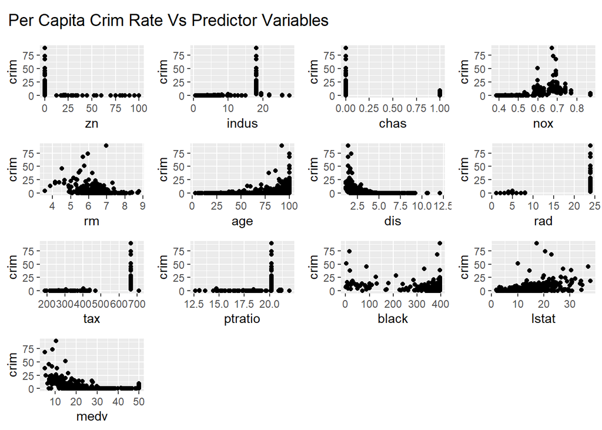

It doesn’t look like I have very good linear relationships between per capita crime and many of the predictors, so a transformation will be in order. Before, I move on, here are the plots of the residuals:

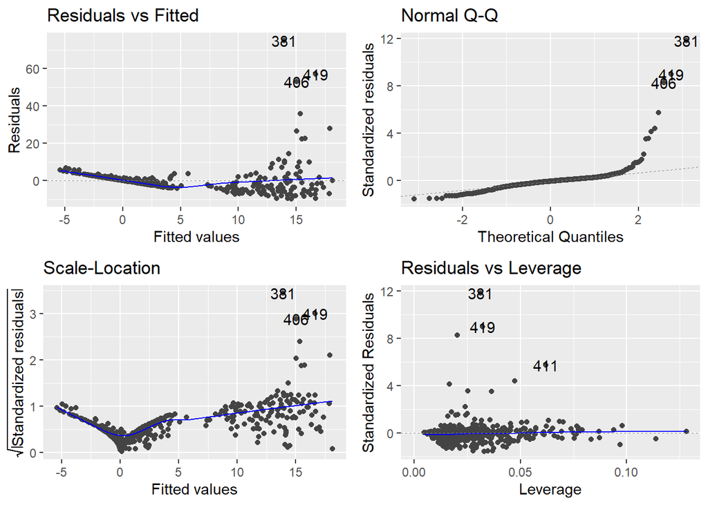

These residual plots show we have some pretty clear violations of the assumptions of linear regression. In the Residuals vs. Fits plot, you can see that the points do not bounce and down nicely around the zero value indicating that they fail to meet the assumption of a linear relationship. Additionally, the points spread out more as you move on down the line indicating that they fail to meet the assumption of equal variance. Looking at the Normal Q-Q plot, the points fail to follow the dashed line, indicating that the residuals fail to meet the assumption of being from a normal distribution.

To rectify this, I will first explore take a log transformation of the predictors. I have taking the log transformation of ( *zn* + 1) because of the zeroes in this variable. I chose not to take a log transformation of *chas* because it is a dummy variable coded with 0 and 1.

Here is the model:

```r
linear.boston.1 <- lm(
  crim ~  log(zn + 1) + log(indus) + chas + log(nox) + log(rm) + log(age) + log(dis)
  + log(rad) + log(tax) + log(ptratio) + log(black) + log(lstat) + log(medv), data = Boston
  )
```

And here is a plot of the relationships between per capita crime and the predictors:

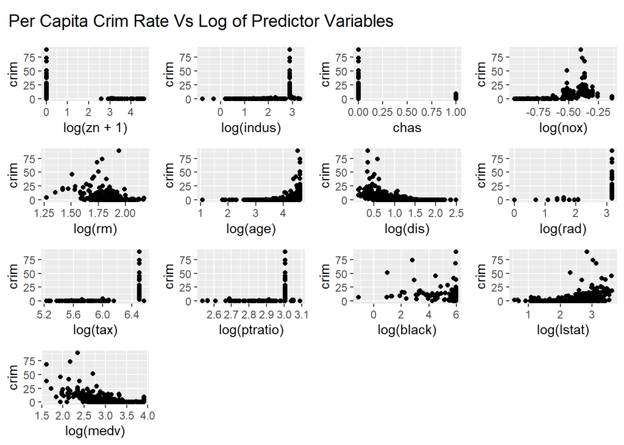

These linear relationships look very slightly better but not significantly so.  
Before trying another transformation, lets check out the residuals:

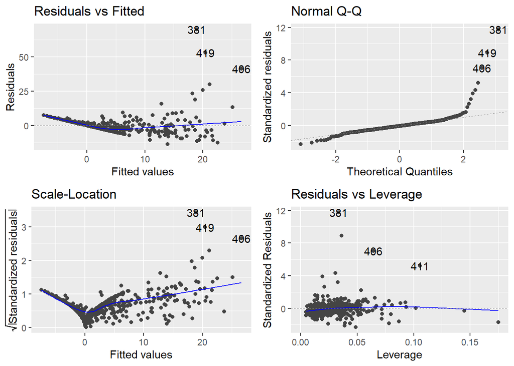

[output not shown]

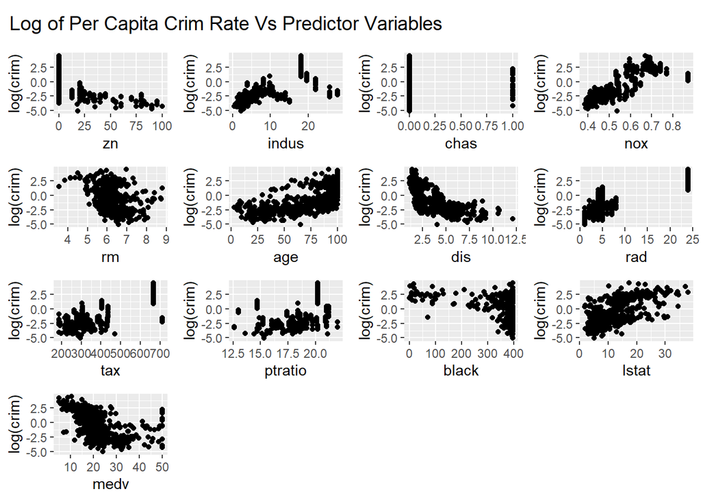

The linear relationships in these plots look significantly better than our previous transformations. To confirm this transformation, we will take a look at our resiudal plots:

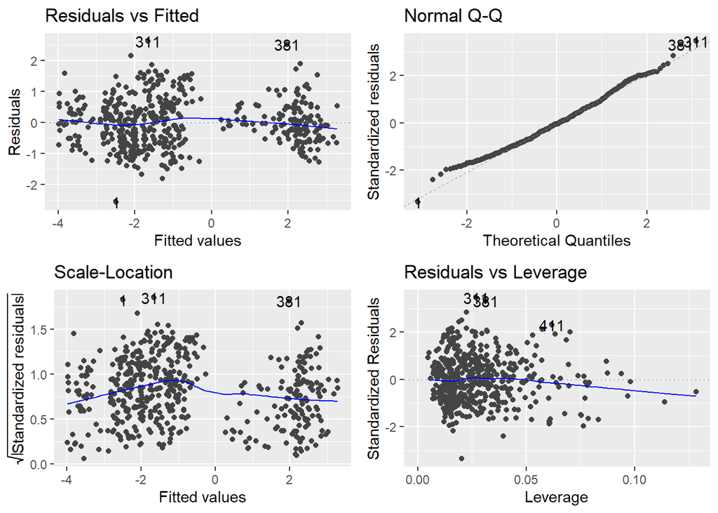

The residual plots also look significiantly better. In the Residuals vs Fitted plot,the points now appear to center around the zero line indicating a linear relationship. The points also appear to maintain a roughly equal distance from that zero line, indicating equal variance. Looking at the Normal Q-Q plot, the points roughly follow the dashed line indicating that the residuals are normally distributed.